# Inferential - Statistics

Pratik Gandhi

May 16, 2016

## Loading and reading the data:

```r
library(tidyr)
library(ggplot2)
library(gridExtra)
basedir <- "C:/Users/Pratik Gandhi/Documents/Data Science Stuff/Projects/Wine_Quality_Data_Set"
setwd(basedir)

# Loading the dataset
wh_wine <- read.csv("winequality-white.csv", header = TRUE)

# Looking at few observations of the data:
head(wh_wine, n = 5)
```

```
##   fixed.acidity.volatile.acidity.citric.acid.residual.sugar.chlorides.free.sulfur.dioxide.total.sulfur.dioxide.density.pH.sulphates.alcohol.quality
## 1                                                                                                  7;0.27;0.36;20.7;0.045;45;170;1.001;3;0.45;8.8;6
## 2                                                                                                6.3;0.3;0.34;1.6;0.049;14;132;0.994;3.3;0.49;9.5;6
## 3                                                                                               8.1;0.28;0.4;6.9;0.05;30;97;0.9951;3.26;0.44;10.1;6
## 4                                                                                              7.2;0.23;0.32;8.5;0.058;47;186;0.9956;3.19;0.4;9.9;6
## 5                                                                                              7.2;0.23;0.32;8.5;0.058;47;186;0.9956;3.19;0.4;9.9;6
```

## Data Munging Part:

### Few of the following things to be done:

1. Renaming the column names.
2. Adding more variables if necessary:

```r
colnames(wh_wine) <- c("all_data")
wh_wine <- wh_wine %>% separate(all_data, c("fixed.acidity", "volatile.acidity",
    "citric.acid", "residual.sugar", "chlorides", "free.sulfur.dioxide", "total.sulfur.dioxide",
    "density", "pH", "sulphates", "alcohol", "quality"), sep = ";")

# Checking the dimension of the data:
dim(wh_wine)
```

```
## [1] 4898   12
```

```r
# Checking the class of the variables:
str(wh_wine)
```

```
## 'data.frame':    4898 obs. of  12 variables:
##  $ fixed.acidity       : chr  "7" "6.3" "8.1" "7.2" ...
##  $ volatile.acidity    : chr  "0.27" "0.3" "0.28" "0.23" ...
##  $ citric.acid         : chr  "0.36" "0.34" "0.4" "0.32" ...
##  $ residual.sugar      : chr  "20.7" "1.6" "6.9" "8.5" ...
##  $ chlorides           : chr  "0.045" "0.049" "0.05" "0.058" ...
##  $ free.sulfur.dioxide : chr  "45" "14" "30" "47" ...
##  $ total.sulfur.dioxide: chr  "170" "132" "97" "186" ...
##  $ density             : chr  "1.001" "0.994" "0.9951" "0.9956" ...
##  $ pH                  : chr  "3" "3.3" "3.26" "3.19" ...
##  $ sulphates           : chr  "0.45" "0.49" "0.44" "0.4" ...
##  $ alcohol             : chr  "8.8" "9.5" "10.1" "9.9" ...
##  $ quality             : chr  "6" "6" "6" "6" ...
```

- Now we have complete “tidy” dataset. The next part would be exploring the data and looking at each of them individually.
- There are 4898 observations and 12 variables.
- Looking at the variables it seems we need to change the class type of each of them if needed.
- Quality is a discrete variable while the others are continuous variables.
- Fixed acidity,volatile acidity and citric acid are related to pH.
- Free sulphur dioxide is contributing/related to total sulphur dioxide.

```r
# Changing the class type and adding more levels
wh_wine$quality <- as.integer(wh_wine$quality)

# Changing the class type of all variables except 'Identifier' and 'Quality'
# variables:
remain_vars <- setdiff(names(wh_wine), c("quality"))
wh_wine[remain_vars] <- sapply(wh_wine[remain_vars], as.numeric)
str(wh_wine)
```

```
## 'data.frame':    4898 obs. of  12 variables:
##  $ fixed.acidity       : num  7 6.3 8.1 7.2 7.2 8.1 6.2 7 6.3 8.1 ...
##  $ volatile.acidity    : num  0.27 0.3 0.28 0.23 0.23 0.28 0.32 0.27 0.3 0.22 ...
##  $ citric.acid         : num  0.36 0.34 0.4 0.32 0.32 0.4 0.16 0.36 0.34 0.43 ...
##  $ residual.sugar      : num  20.7 1.6 6.9 8.5 8.5 6.9 7 20.7 1.6 1.5 ...
##  $ chlorides           : num  0.045 0.049 0.05 0.058 0.058 0.05 0.045 0.045 0.049 0.044 ...
##  $ free.sulfur.dioxide : num  45 14 30 47 47 30 30 45 14 28 ...
##  $ total.sulfur.dioxide: num  170 132 97 186 186 97 136 170 132 129 ...
##  $ density             : num  1.001 0.994 0.995 0.996 0.996 ...
##  $ pH                  : num  3 3.3 3.26 3.19 3.19 3.26 3.18 3 3.3 3.22 ...
##  $ sulphates           : num  0.45 0.49 0.44 0.4 0.4 0.44 0.47 0.45 0.49 0.45 ...
##  $ alcohol             : num  8.8 9.5 10.1 9.9 9.9 10.1 9.6 8.8 9.5 11 ...
##  $ quality             : int  6 6 6 6 6 6 6 6 6 6 ...
```

```r
# Summarizing the dataset:
summary(wh_wine)
```

```
##  fixed.acidity    volatile.acidity  citric.acid     residual.sugar
##  Min.   : 3.800   Min.   :0.0800   Min.   :0.0000   Min.   : 0.600
##  1st Qu.: 6.300   1st Qu.:0.2100   1st Qu.:0.2700   1st Qu.: 1.700
##  Median : 6.800   Median :0.2600   Median :0.3200   Median : 5.200
##  Mean   : 6.855   Mean   :0.2782   Mean   :0.3342   Mean   : 6.391
##  3rd Qu.: 7.300   3rd Qu.:0.3200   3rd Qu.:0.3900   3rd Qu.: 9.900
##  Max.   :14.200   Max.   :1.1000   Max.   :1.6600   Max.   :65.800
##    chlorides       free.sulfur.dioxide total.sulfur.dioxide    density
##  Min.   :0.00900   Min.   :  2.00      Min.   :  9.0        Min.   :0.9871
##  1st Qu.:0.03600   1st Qu.: 23.00      1st Qu.:108.0        1st Qu.:0.9917
##  Median :0.04300   Median : 34.00      Median :134.0        Median :0.9937
##  Mean   :0.04577   Mean   : 35.31      Mean   :138.4        Mean   :0.9940
##  3rd Qu.:0.05000   3rd Qu.: 46.00      3rd Qu.:167.0        3rd Qu.:0.9961
##  Max.   :0.34600   Max.   :289.00      Max.   :440.0        Max.   :1.0390
##        pH          sulphates         alcohol         quality
##  Min.   :2.720   Min.   :0.2200   Min.   : 8.00   Min.   :3.000
##  1st Qu.:3.090   1st Qu.:0.4100   1st Qu.: 9.50   1st Qu.:5.000
##  Median :3.180   Median :0.4700   Median :10.40   Median :6.000
##  Mean   :3.188   Mean   :0.4898   Mean   :10.51   Mean   :5.878
##  3rd Qu.:3.280   3rd Qu.:0.5500   3rd Qu.:11.40   3rd Qu.:6.000
##  Max.   :3.820   Max.   :1.0800   Max.   :14.20   Max.   :9.000
```

```r
# Quality of wines:
table(wh_wine$quality)
```

```
##
##    3    4    5    6    7    8    9
##   20  163 1457 2198  880  175    5
```

## Univariate Exploration and Analysis:

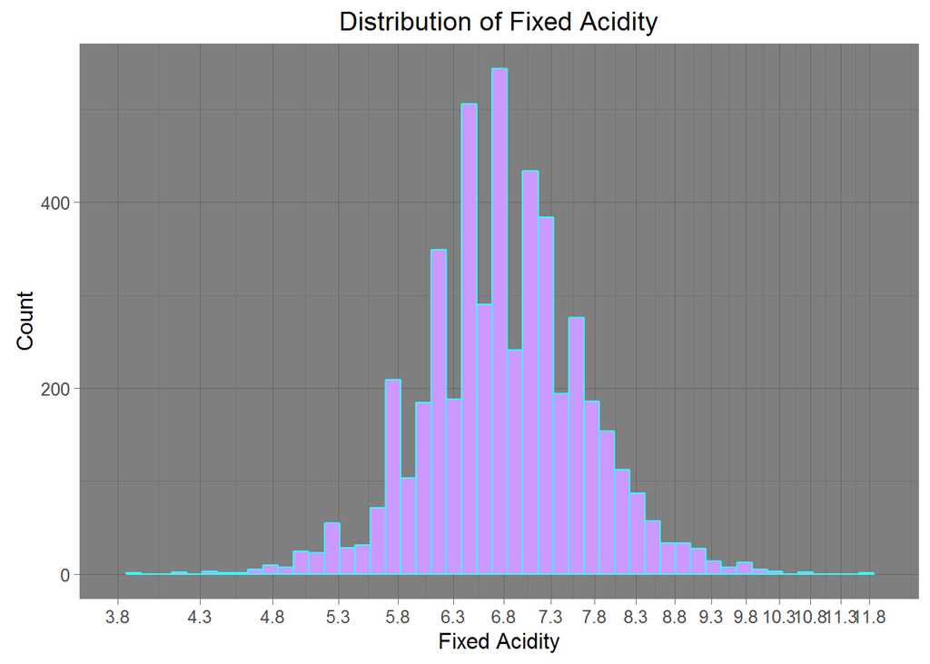

```r
# ggpairs(wh_wine)

# Fixed Acidity:
ggplot(wh_wine, aes(fixed.acidity)) + geom_histogram(binwidth = 0.01, color = "#33FFFF",
    fill = "#CC99FF") + ggtitle("Distribution of Fixed Acidity") + scale_x_log10(breaks = seq(min(wh_wine$fixed.acidity),
    12, 0.5), lim = c(min(wh_wine$fixed.acidity), 12)) + xlab("Fixed Acidity") +
    ylab("Count") + theme_dark()
```

#### The distribution of fixed acidity looks pretty normal. There might be couple of outliers on both tails.

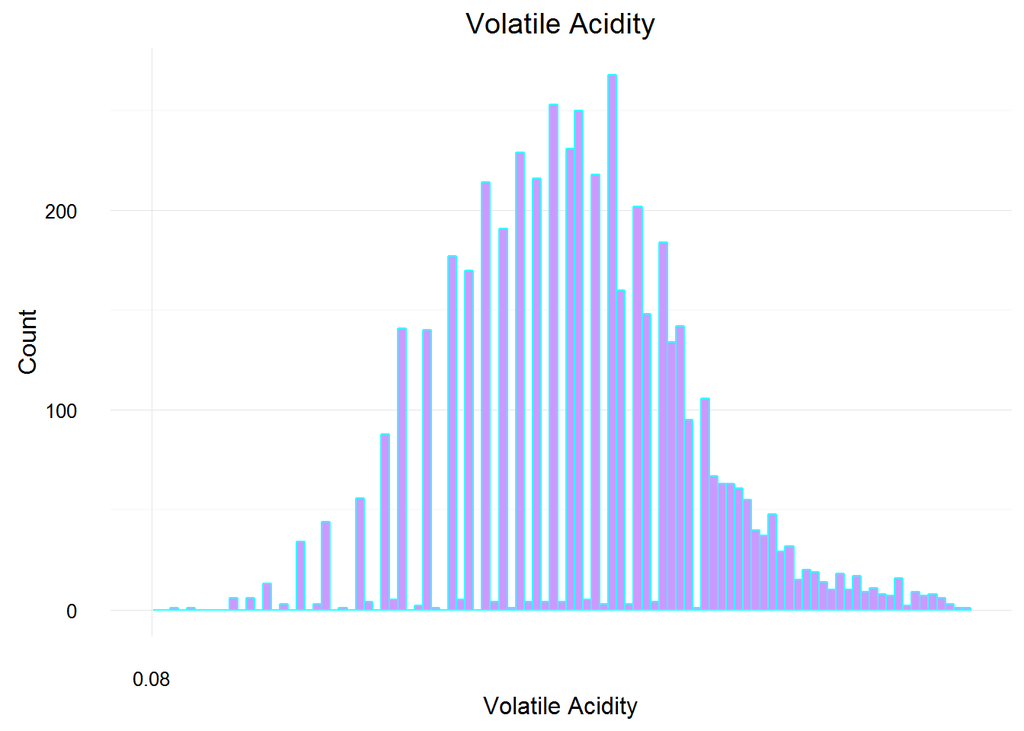

```r
# Volatile Acidity:
ggplot(wh_wine, aes(volatile.acidity)) + geom_histogram(binwidth = 0.01, color = "#33FFFF",
    fill = "#CC99FF") + ggtitle("Volatile Acidity") + scale_x_log10(breaks = seq(min(wh_wine$volatile.acidity),
    0.75), lim = c(min(wh_wine$volatile.acidity), 0.75)) + xlab("Volatile Acidity") +
    ylab("Count") + theme_minimal()
```